# FigureYa67phastCons

# Academic Citation

If you use this code in your work or research, we kindly request that you cite our publication:

Xiaofan Lu, et al. (2025). FigureYa: A Standardized Visualization Framework for Enhancing Biomedical Data Interpretation and Research Efficiency. iMetaMed. https://doi.org/10.1002/imm3.70005

## 需求描述

输入ucsc上的phastCons文件、ChIP-seq的peak bed文件。用R或python计算数值，用R画出conservation profile

## Requirement Description

Input phastCons file on ucsc, peak bed file on ChIP-seq. Calculate values in R or python, draw conservation profile in R

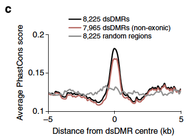

出自https://www.nature.com/articles/ncomms7315

fromhttps://www.nature.com/articles/ncomms7315

## 应用场景

展示特定区域的保守性。

重要区域保守性往往较高，例如转录因子结合位点。

## Application Scenarios

Demonstrate the conserved nature of specific regions.

Important regions tend to be highly conserved, such as transcription factor binding sites.

## 环境设置

操作系统：Linux或MAC。

需要用到awk、python2.7

下载bigWigSummary：

## Environment settings

OS: Linux or MAC.

Requires awk, python2.7

Download bigWigSummary:

```r
## choose by platform & cpu type
## macOSX
#download.file("http://hgdownload.soe.ucsc.edu/admin/exe/macOSX.x86_64/bigWigSummary","bigWigSummary")
## linux x86_64
#download.file("http://hgdownload.soe.ucsc.edu/admin/exe/linux.x86_64/bigWigSummary","bigWigSummary")
## linux x86_64 v369
#download.file("http://hgdownload.soe.ucsc.edu/admin/exe/linux.x86_64.v369/bigWigSummary","bigWigSummary")

#Sys.chmod(c("bigWigSummary"),755)
```

## 输入文件

此处对比all dsDMR、non exon dsDMR和随机序列这三个bed的phastCons

- all_dsDMR.bed, non_exon_dsDMR.bed, download from https://epigenome.wustl.edu/Zebrafish_DNAme/browse.php
- random.bed, random regions generation (randomBed -l 500 -n 8225 -seed 6666 -g danRer7.chrom.sizes > random.bed)
- fish.phastCons8way.bw，保守性文件，下载的步骤：

Step1.进入物种选择页面，http://genome.ucsc.edu/

## Input file

Here we compare the phastCons for the three beds all dsDMR, non exon dsDMR and random sequence

- all_dsDMR.bed, non_exon_dsDMR.bed, download from https://epigenome.wustl.edu/Zebrafish_DNAme/browse.php
- random.bed, random regions generation (randomBed -l 500 -n 8225 -seed 6666 -g danRer7.chrom.sizes > random.bed)
- Steps to download fish.phastCons8way.bw, the conservativeness file:

Step1. enter the species selection page, http://genome.ucsc.edu/

[figure not shown]

Step2.选择物种和基因组版本

Step2. Selecting species and genome versions

[figure not shown]

Step3.找到保守性记录

Step3. Finding the Conservative Record

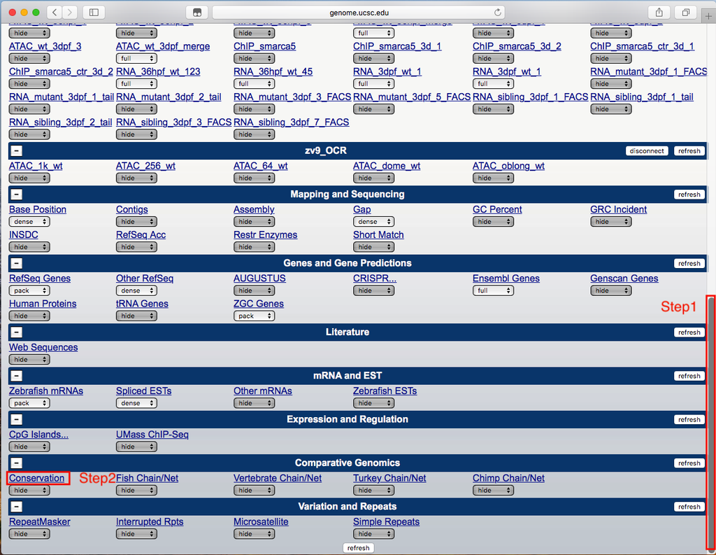

Step4.找到保守性文件存放文件夹

Step4. Locate the folder where the conservative documents are stored.

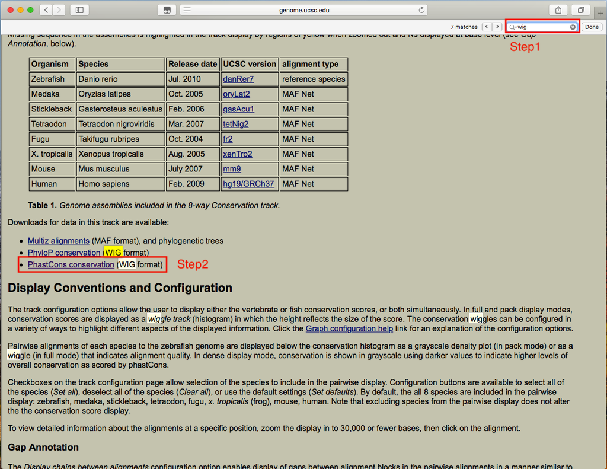

Step5.找到保守性文件

Step5. Finding Conservative Documents

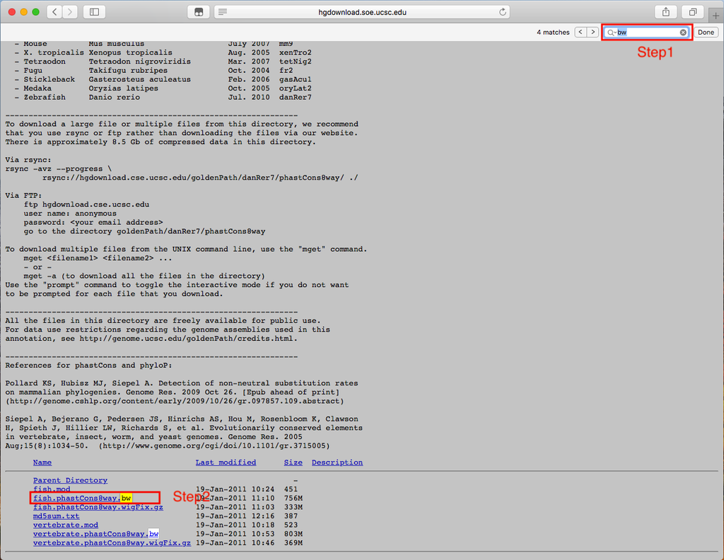

Step6.下载保守性文件

Step6.Download Conservative Documents

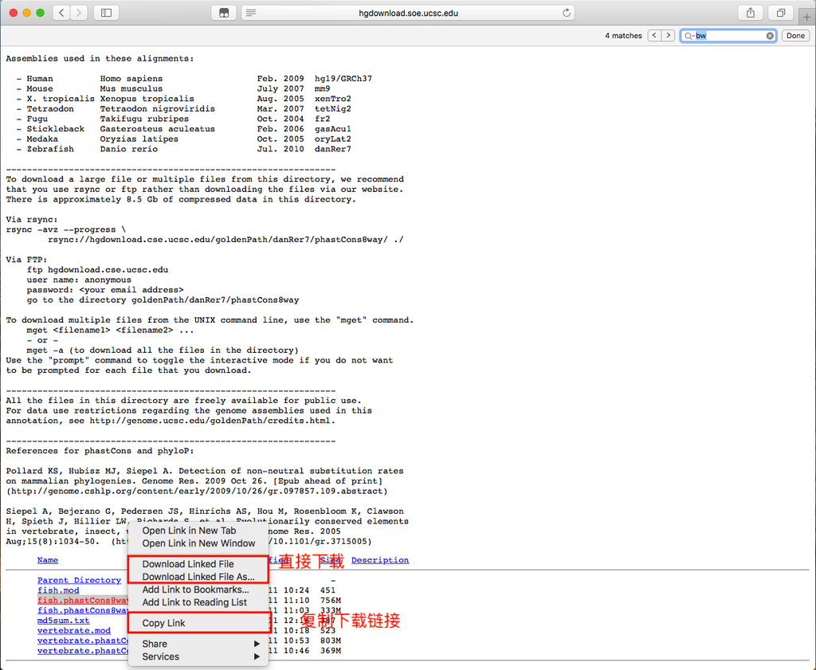

## Parameter setting

```r
source("install_dependencies.R")
```

[output not shown]

[output not shown]

[output not shown]

[output not shown]

[output not shown]

[output not shown]

```r
# 输出设置 / Output settings
outputName <- "phastCons_example.pdf"
# 输出的PDF文件名 / Name of the output PDF file
# 用于保存后续绘制的图形 / Used to save subsequent plots

# 输入文件设置 / Input file settings
bigWigFile <- c("fish.phastCons8way.bw")
# 进化保守性分数文件 / Evolutionary conservation score file (bigWig format)
# 包含跨物种序列保守性数据 / Contains cross-species sequence conservation data

bedFiles <- c("all_dsDMR.bed","non_exon_dsDMR.bed","random.bed")
# 需要分析的基因组区域文件 / Genomic region files to analyze:
# 1. 所有差异甲基化区域 / All differentially methylated regions (DMRs)
# 2. 非外显子差异甲基化区域 / Non-exonic DMRs
# 3. 随机区域作为对照 / Random regions as control

# 图例标签设置 / Legend label settings
labels <- c("8,225 dsDMRs","7,965 dsDMRs (non-exonic)","8,225 random regions")
# 将显示在图形图例中的文本 / Text to display in the plot legend:
# 注意数字应与实际数据一致 / Note: Numbers should match actual data counts

# 坐标轴标签设置 / Axis label settings
siteType <- "dsDMR centre"
# X轴标题将显示为"Distance from dsDMR centre" / X-axis title will show as "Distance from..."
# 可根据实际分析目标修改 / Can be modified based on analysis target

# 分析参数设置 / Analysis parameters
resolution <- 50
# 分析分辨率(碱基对) / Resolution in base pairs
# 控制数据点密度 / Controls data point density

span <- 5000
# 分析区域跨度(碱基对) / Analysis span in base pairs
# 从中心点向两侧延伸的范围 / Extends this distance from center point

coreNumber <- 3
# 并行计算使用的CPU核心数 / Number of CPU cores for parallel computing
# 根据计算机配置调整 / Adjust based on computer configuration

# 图形颜色设置 / Color settings
colors <- c("black", "indianred3", "gray")
# 三条曲线的显示颜色 / Colors for the three lines:
# 1. 所有DMRs / All DMRs (black)
# 2. 非外显子DMRs / Non-exonic DMRs (red)
# 3. 随机区域 / Random regions (gray)

# 计算方法设置 / Computation method
captureMethod <- "security"
# 信号捕获计算方法 / Signal capture calculation method
# 其他可选方法可能包括"basic"等 / Other options may include "basic" etc.
```

## 提取信号

### 先写个函数，函数里面会调用getBigWigValue.py，位于当前文件夹

## Extracting signals

### Write a function that calls getBigWigValue.py, located in the current folder.

```r
regionCapture <- function(seqname, start, end, bw, datapoints, captureMethod="security", cores=4L) {
  # 捕获基因组区域内bigwig信号 / Capture bigwig signals in genomic regions
  # 参数说明 / Parameters:
  #   seqname - 染色体名称向量 / Vector of chromosome names
  #   start - 起始位置向量 / Vector of start positions
  #   end - 结束位置向量 / Vector of end positions
  #   bw - bigwig文件路径 / Path to bigwig file
  #   datapoints - 每个区域采样点数 / Number of datapoints per region
  #   captureMethod - 计算方法，默认"security" / Calculation method, default "security"
  #   cores - 使用CPU核心数，默认4 / Number of CPU cores to use, default 4

  # 创建BED格式区域文件 / Create BED format region file
  captureRegion <- data.frame(seqname=seqname, start=start, end=end)
  write.table(captureRegion, file="captureRegion.bed",
              quote=FALSE, sep="\t", row.names=FALSE, col.names=FALSE)

  # 调用Python脚本处理bigwig文件 / Call Python script to process bigwig file
  suppressMessages(
    system(paste("python getBigWigValue.py -b", "captureRegion.bed",
                "-w", bw, "-n regionCapture",
                "-p", cores, "-s", datapoints,
                "-m", captureMethod))
  )

  # 读取处理结果 / Read processed results
  signal <- read.table(gzfile("signal_regionCapture_siteprof1.gz"))

  return(signal)
}

signal_caputer_around_sites <- function(bigWigFile, bed, resolution=50,
                                       span=3000, captureMethod="security",
                                       cores=4L) {
  # 计算位点周围平均信号 / Calculate average signals around sites
  # 参数说明 / Parameters:
  #   bigWigFile - bigwig文件路径 / Path to bigwig file
  #   bed - BED格式数据框 / BED format dataframe
  #   resolution - 分辨率(bp)，默认50 / Resolution in bp, default 50
  #   span - 分析区域跨度(bp)，默认3000 / Analysis span in bp, default 3000
  #   captureMethod - 计算方法，默认"security" / Calculation method, default "security"
  #   cores - 使用CPU核心数，默认4 / Number of CPU cores, default 4

  # 计算总数据点数 / Calculate total datapoints
  datapoints <- span * 2 / resolution + 1  # 包括中心点 / Including center point

  # 提取染色体名称 / Extract chromosome names
  seqname <- bed[,1]

  # 计算位点中心位置 / Calculate site center positions
  midpoints <- as.integer((bed[,2] + bed[,3] - 1) / 2)  # BED是0-based / BED is 0-based

  # 获取链方向信息 / Get strand information
  if(ncol(bed) > 5) {
    strand <- bed[,6]  # 第6列为链信息 / Column 6 contains strand info
  } else {
    strand <- rep(".", nrow(bed))  # 默认无链信息 / Default no strand info
  }

  # 捕获信号 / Capture signals
  signal <- regionCapture(seqname,
                         midpoints-span-resolution/2,  # 起始位置 / Start position
                         midpoints+span+resolution/2,  # 结束位置 / End position
                         bigWigFile, datapoints, captureMethod, cores)

  # 校正链方向并计算平均信号 / Correct strand orientation & calculate average signal
  write.table(signal, file="temp_signal.txt",
             quote=FALSE, row.names=FALSE, col.names=FALSE, sep="\t")
  write.table(strand, file="temp_strand.txt",
             quote=FALSE, row.names=FALSE, col.names=FALSE, sep="\t")

  # 使用awk处理反向链信号 / Use awk to process reverse strand signals
  system(paste0("paste temp_signal.txt temp_strand.txt | awk '{if($NF==",
               '"',"+",'"',") {for(i=1;i<NF-1;i++) printf $i",
               '"',"\t",'"',"; print $(NF-1)} else {for(i=NF-1;i>1;i--) printf $i",
               '"',"\t",'"',"; print $1}}' > temp_signal_rev.txt"))

  # 使用data.table高效读取 / Use data.table for efficient reading
  signal_rev <- data.table::fread("temp_signal_rev.txt")

  # 清理临时文件 / Clean up temporary files
  file.remove("temp_signal.txt")
  file.remove("temp_strand.txt")
  file.remove("temp_signal_rev.txt")

  # 返回各位置平均信号 / Return average signals at each position
  return(apply(signal_rev, 2, mean))
}
```

### Extract the signal

```r
# 初始化平均信号矩阵 / Initialize average signal matrix
# 用于存储所有BED文件的分析结果 / To store results from all BED files
average_signal <- c()

# 循环处理每个BED文件 / Loop through each BED file
for(i in 1:length(bedFiles)) {

  # 加载BED文件 / Load BED file
  # bedFiles是包含多个BED文件路径的字符向量 / bedFiles is a character vector containing paths to multiple BED files
  bed <- read.table(bedFiles[i])

  # 过滤非常规染色体 / Filter non-standard chromosomes
  # 只保留不包含下划线的常规染色体(如chr1, chrX等) / Keep only standard chromosomes without underscores (e.g. chr1, chrX)
  # 注意：某些基因组可能包含"chrUn_"或随机染色体等 / Note: Some genomes may contain "chrUn_" or random chromosomes
  isNormalChrosome <- !grepl("_", bed$V1)  # V1列通常是染色体名称 / Column V1 is usually chromosome name
  bed <- bed[isNormalChrosome, ]

  # 捕获位点周围信号并保存结果 / Capture signals around sites and store results
  # 使用signal_caputer_around_sites函数处理每个BED文件 / Process each BED file using signal_caputer_around_sites function
  average_signal <- rbind(average_signal,
                         signal_caputer_around_sites(
                           bigWigFile = bigWigFile,  # 保守性分数文件 / Conservation score file
                           bed = bed,                # 当前BED文件数据 / Current BED file data
                           resolution = resolution,  # 分析分辨率 / Analysis resolution
                           span = span,              # 分析范围 / Analysis span
                           captureMethod = captureMethod,  # 计算方法 / Calculation method
                           cores = as.integer(coreNumber)  # 并行计算核心数 / Number of cores for parallel computing
                         ))

  # 可选的进度提示 / Optional progress message
  if(i %% 1 == 0) {  # 每处理1个文件显示进度 / Show progress after each file
    message("已完成 ", i, "/", length(bedFiles), " (", round(i/length(bedFiles)*100, 1), "%)")
    utils::flush.console()  # 确保立即显示消息 / Ensure immediate message display
  }
}
```

```
## 已完成 1/3 (33.3%)
```

```
## 已完成 2/3 (66.7%)
```

```
## 已完成 3/3 (100%)
```

```r
# 保存平均信号结果 / Save average signal results
# 将结果写入CSV文件以便后续分析 / Write results to CSV file for subsequent analysis
write.csv(average_signal,
          file = "average_signal.csv",  # 输出文件名 / Output filename
          quote = FALSE,               # 不添加引号 / Do not add quotes
          row.names = FALSE)           # 不保存行名 / Do not save row names

# 补充说明 / Additional notes:
# 1. 结果文件包含三类区域的保守性分数 / The output contains conservation scores for three region types
# 2. 每行对应一个BED文件的分析结果 / Each row corresponds to a BED file's results
# 3. 列对应基因组位置(从-span到+span) / Columns correspond to genomic positions (-span to +span)
# 4. 建议后续使用read.csv()读取时检查维度 / Recommend checking dimensions when reading with read.csv()
```

## Start drawing

```r
# 读取保存的平均信号数据 / Load saved average signal data
average_signal <- read.csv("average_signal.csv")

# 查看数据首尾部分 / Preview beginning and end of data
head(average_signal[,c(1:3,(ncol(average_signal)-2):ncol(average_signal))])
```

```
##          V1        V2        V3      V199      V200      V201
## 1 0.1150350 0.1154582 0.1176155 0.1185914 0.1161026 0.1148453
## 2 0.1150350 0.1154582 0.1176155 0.1185914 0.1161026 0.1148453
## 3 0.1137995 0.1176929 0.1165951 0.1196118 0.1138679 0.1160808
```

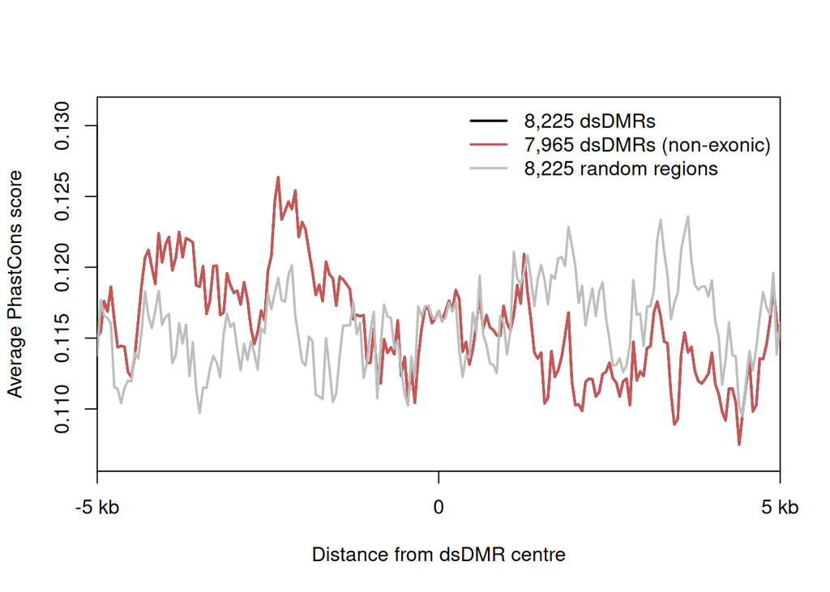

```r
# 显示前3列和最后3列 / Shows first 3 and last 3 columns
# 帮助检查数据范围和完整性 / Helps check data range and integrity

# 设置Y轴显示范围 / Set y-axis display range
minimum <- min(average_signal) - (max(average_signal) - min(average_signal)) * 0.1
# 最小值下扩10%范围 / Extend 10% below minimum
maximum <- max(average_signal) + (max(average_signal) - min(average_signal)) * 0.1 * length(bedFiles)
# 最大值上扩10%×样本数范围 / Extend 10%×number of samples above maximum

# 计算数据点数量 / Calculate number of datapoints
datapoints <- span / resolution  # 单侧数据点数 / Datapoints on one side

# 创建图形输出 / Create graphic output
# pdf(outputName, width = 6, height = 5)  # 已注释，实际使用时取消 / Commented out, uncomment for actual use

# 绘制第一条线 (基准线) / Plot first line (baseline)
plot(1:(datapoints*2+1),  # X轴位置 / X-axis positions
     average_signal[1,],   # Y轴值 / Y-axis values
     type="l",             # 线图 / Line plot
     lwd = 2,              # 线宽 / Line width
     col=colors[1],        # 颜色 / Color
     xaxs="i", yaxs="i",   # 坐标轴紧贴数据范围 / Axes fit data range exactly
     xaxt="n",             # 暂时关闭X轴 / Temporarily disable x-axis
     xlab=paste("Distance from", siteType),  # X轴标签 / X-axis label
     ylab="Average PhastCons score",         # Y轴标签 / Y-axis label
     ylim=c(minimum, maximum))              # Y轴范围 / Y-axis range

# 添加其他样本的线 / Add lines for other samples
for(i in 2:length(bedFiles)){
  lines(1:(datapoints*2+1),
        average_signal[i,],
        lwd = 2,
        col=colors[i])  # 使用预定义颜色 / Use predefined colors
}

# 添加图例 / Add legend
legend("topright",         # 图例位置 / Legend position
       col=colors,         # 颜色 / Colors
       legend=labels,      # 标签文本 / Label text
       lty=1,              # 线型 / Line type
       lwd = 2,            # 线宽 / Line width
       bty="n")            # 无边框 / No border

# 自定义X轴 / Customize x-axis
axis(side=1,  # 底部X轴 / Bottom x-axis
     at=c(0, datapoints, datapoints * 2) + 1,  # 刻度位置 / Tick positions
     labels = c(paste(-1*span/1000,"kb"),       # 左侧标签 / Left label
               "0",                             # 中心点 / Center point
               paste(span/1000,"kb")))          # 右侧标签 / Right label
```

```r
# 关闭图形设备 (与pdf()配对使用) / Close graphic device (paired with pdf())
# dev.off()  # 已注释，实际使用时取消 / Commented out, uncomment for actual use
```